# Hyperion fire detection - April 2014

## Load prerequisites, filepaths, libraries

Imports.

```python
%pylab inline
import numpy as np
import h5py
import os.path
import random
import time
import pickle
import json
from itertools import izip_longest
import matplotlib.pyplot as plt
from pygaarst import raster
from pygaarst import landsatutils as l
from pygaarst import hyperionutils as hyp
from pygaarst import irutils as ir
from pygaarst import rasterhelpers as rh
import brewer2mpl
from scipy import stats
from sklearn.cluster import MiniBatchKMeans
```

```
WARNING: pylab import has clobbered these variables: ['f', 'random', 'colors']
`%matplotlib` prevents importing * from pylab and numpy
```

Set up plot options.

```python
bmap = brewer2mpl.get_map('Set1', 'qualitative', 7)
colors = bmap.mpl_colors
mpl.rcParams['axes.color_cycle'] = colors
matplotlib.rcParams.update({'font.size': 18, 'font.family': 'Calibri'})
```

For interactive work, Pygaarst libraries need re-importing after editing.

```python
reload(raster)
reload(ir)
reload(l)
reload(hyp)
reload(rh)
```

```
<module 'pygaarst.rasterhelpers' from '/Users/chris/Dropbox/Research/pygaarst/pygaarst/rasterhelpers.pyc'>
```

Directory and file names.

```python
basedir = "/Volumes/SCIENCE/Fire/DATA_BY_PROJECT/HyspIRI_Prep_2014/"
outdir = "/Volumes/SCIENCE/Fire/DATA_BY_PROJECT/HyspIRI_Prep_2014/visual/tmp/"
dir_2004 = "2004Boundary"
dir_2009 = "2009WoodRiver"
hypscene_2004 = "EO1H0690142004201110PX"
aliscene_2004 = "EO1A0690142004201110PX"
landsatscene_2004 = "LE70690142004201EDC01"
hypscene_2009 = "EO1H0690142009214110KF"
aliscene_2009 = "EO1A0690142009214110KF"
landsatscene_2009 = "LT50680152009215GLC00"  # There is also a simultaneous L7 scene, LE70690152009214EDC00, but it's stripey
```

```python
hyp2004 = raster.Hyperionscene(os.path.join(basedir, dir_2004, hypscene_2004))
hyp2004.infix = '_CLIP'
hyp2009 = raster.Hyperionscene(os.path.join(basedir, dir_2009, hypscene_2009))
hyp2009.infix = '_CLIP'
```

Select year to work on:

```python
fireyear = 2004

if fireyear == 2004:
    hypsc = hyp2004
    firename = 'boundary'
elif fireyear == 2009:
    hypsc = hyp2009
    firename = 'woodriver'
else:
    raise Exception("Fireyear not implemented.")
```

## Load data: radiance, fire and buffer candidate pixels

Sample band to use for rough fire detection

```python
b220 = hypsc.band220
```

```python
b220.radiance.dtype
```

```
dtype('float32')
```

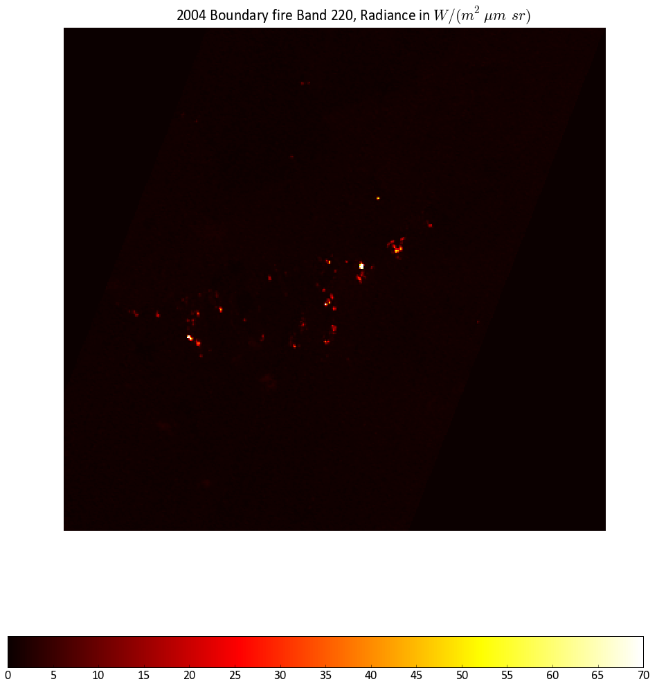

```python
saveout = False
f, ax = plt.subplots(figsize=(15, 25))
#output = ax.imshow(b220.radiance, cmap='hot', clim=(0, 70))
output = ax.pcolor(np.flipud(b220.radiance), cmap='hot', vmin=0, vmax=70)
ax.set_title("%s %s fire Band 220, Radiance in $W / (m^2 \mu m\, sr)$" % (fireyear, firename.capitalize()))
ax.set_aspect('equal')
ax.set_axis_off()
if fireyear == 2004:
    position=f.add_axes([0.05, 0.2, 0.85, 0.025])
else:
    position=f.add_axes([0.05, 0.01, 0.85, 0.025])
plt.colorbar(output, orientation='horizontal', cax=position, ticks=range(0, 75, 5))
#plt.colorbar(output, orientation='horizontal', pad=0.025, shrink=0.85)
if saveout:
    plt.tight_layout()
    outfile = os.path.join(outdir, "rad%s_plot.png" % fireyear)
    plt.savefig(outfile,  bbox_inches='tight', dpi=150)
```

Fire candidate pixels

```python
i_fire, j_fire = np.where(b220.radiance > 5.)
print(zip(i_fire, j_fire))
print(len(i_fire))
```

```
[(37, 164), (37, 165), (37, 169), (38, 164), (38, 165), (64, 91), (88, 156), (88, 157), (116, 216), (116, 217), (117, 216), (117, 217), (118, 216), (118, 217), (135, 252), (135, 253), (136, 252), (136, 253), (144, 233), (144, 234), (145, 232), (145, 233), (145, 234), (146, 226), (146, 227), (146, 23…
298
```

Calculate the mask of fire candidate pixels from simple thresholding. Then plot the fire mask.

```python
firemask = np.zeros(b220.data.shape)
firemask[b220.radiance > 5.] = 1.
```

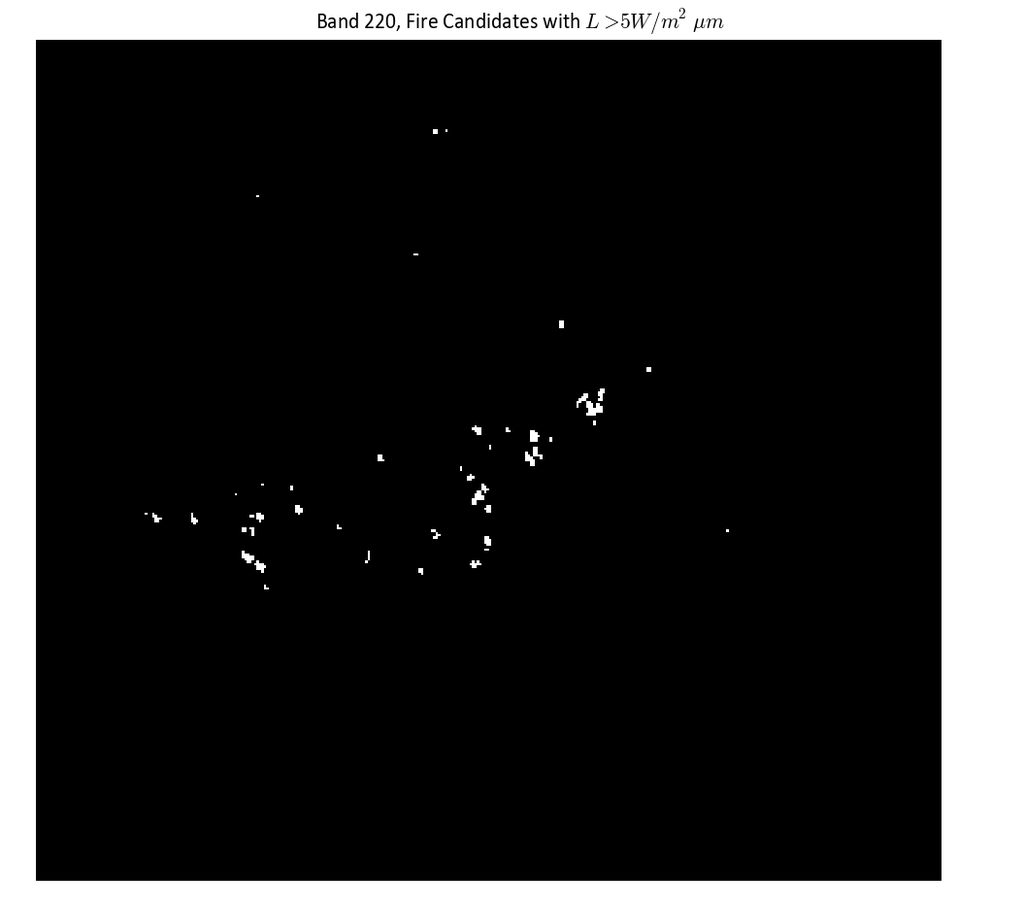

```python
saveout = False
f, ax = plt.subplots(figsize=(15, 25))
output = ax.pcolor(np.flipud(firemask), cmap='bone', vmin=0, vmax=1)
ax.set_title("Band 220, Fire Candidates with $L > 5 W / m^2 \mu m$")
ax.set_aspect('equal')
ax.set_axis_off()
plt.tight_layout()
if saveout:
    outfile = os.path.join(outdir, "fire01_%s_plot.png" % fireyear)
    plt.savefig(outfile,  bbox_inches='tight', dpi=150)
    plt.close()
```

Calculate a square buffer around each pixel in the firemask, N pixels in east/west and north/south direction. (E.g., N=10: 300m). Then plot the buffered mask.

```python
N = 10
firemask_ext = np.zeros(b220.data.shape)
for i, j in zip(i_fire, j_fire):
    firemask_ext[i-N:i+N+1, j-N:j+N+1] = 0.5
firemask_ext[b220.radiance > 5.] = 1.
```

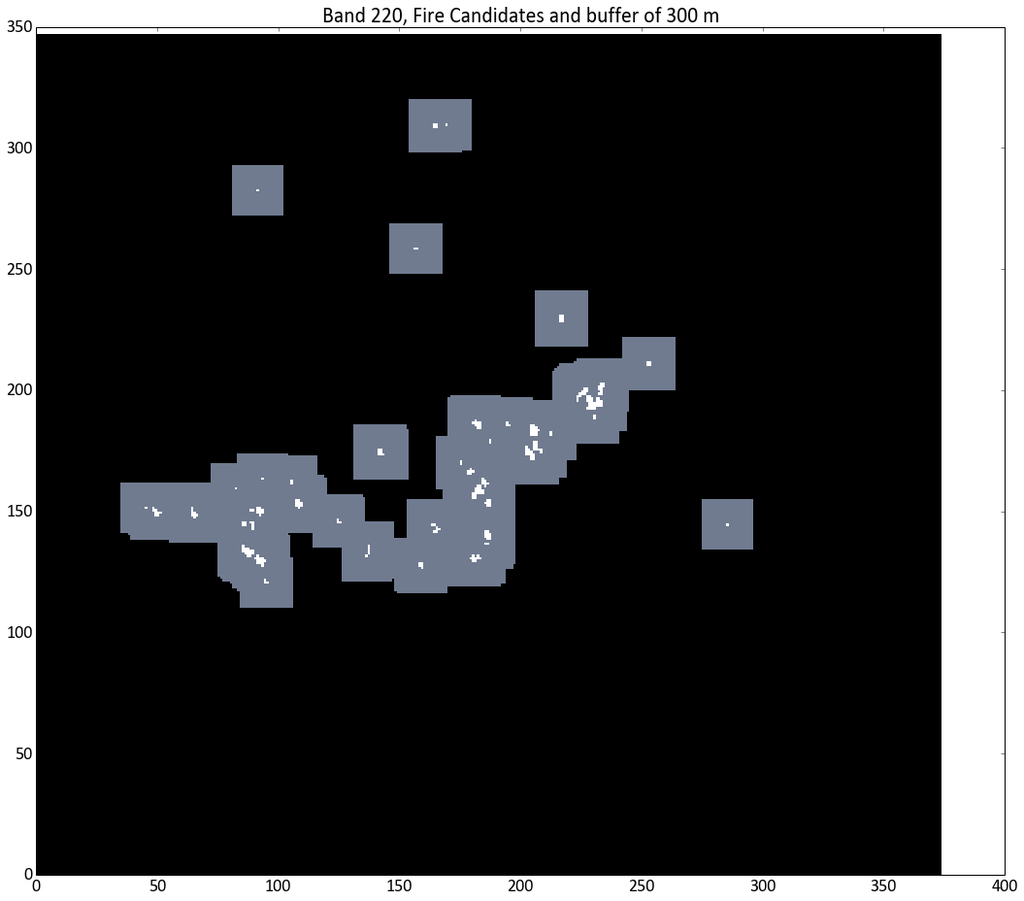

```python
saveout = False
f, ax = plt.subplots(figsize=(15, 25))
output = ax.pcolor(np.flipud(firemask_ext), cmap='bone', vmin=0, vmax=1)
ax.set_title("Band 220, Fire Candidates and buffer of %s m" % str(N*30))
ax.set_aspect('equal')
#ax.set_axis_off()
plt.tight_layout()
if saveout:
    outfile = os.path.join(outdir, "fire01_buff_%s_plot.png" % fireyear)
    plt.savefig(outfile,  bbox_inches='tight', dpi=150)
    plt.close()
```

Let's save the masks to a TIF file.

```python
firemask_ds = b220.clone(os.path.join(outdir, '%sfire_01.tif' % firename), firemask_ext)
firemask_ext_ds = b220.clone(os.path.join(outdir, '%sfire_ext01.tif' % firename), firemask_ext)
```

## Fire detection with normalized difference index: HFDI

```python
#hfdi2 = hypsc.get_normdiff('band224', 'band191')
hfdi2 = hypsc.get_normdiff('band217', 'band196')
```

```
WARNING:pygaarst.irutils:NaN generated while calculating normalized difference index: : Warning: invalid value encountered in divide
```

```python
thresh = -0.1515
np.nansum(hfdi2 > thresh)
```

```
WARNING:pygaarst.irutils:NaN generated while calculating normalized difference index: : Warning: invalid value encountered in greater
```

```
2223
```

```
WARNING:pygaarst.irutils:NaN generated while calculating normalized difference index: : Warning: invalid value encountered in divide

WARNING:pygaarst.irutils:NaN generated while calculating normalized difference index: : Warning: invalid value encountered in greater
```

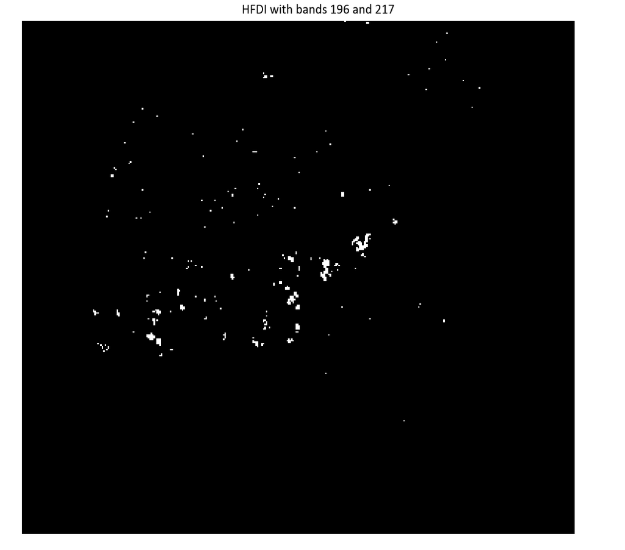

```python
thresh = -0.1515
b1 = 196
b2 = 217

firemean = -0.052600
fireSDT = 0.048500
thresh_hSTD = firemean - 0.5 * fireSDT

hfdi2 = hypsc.get_normdiff('band217', 'band196')
hfdimask = np.zeros(b220.data.shape)
hfdimask[hfdi2>thresh_hSTD] = 1

saveout = False
f, ax = plt.subplots(figsize=(15, 25))
output = ax.pcolor(np.flipud(hfdimask), cmap='bone', vmin=0, vmax=1)
ax.set_title("HFDI with bands %s and %s" % (b1, b2))
ax.set_aspect('equal')
ax.set_axis_off()
plt.tight_layout()
if saveout:
    outfile = os.path.join(outdir, "HFDI_%s_%s_%s_plot.png" % (b1, b2, fireyear))
    plt.savefig(outfile,  bbox_inches='tight', dpi=150)
    plt.close()
```

Save HFDI to file

```python
thresh = -0.1515
hfdi_thresh = np.zeros(b220.data.shape, dtype='uint8')
hfdi_thresh[np.logical_and(hfdi2 > thresh, ~np.isnan(hfdi2))] = 255
hfdi_thresh_ds = b220.clone(os.path.join(outdir, '%s_hfdi_thresh_%s_%s.tif' % (firename, b1, b2)), hfdi_thresh)
```

```
WARNING:pygaarst.irutils:NaN generated while calculating normalized difference index: : Warning: invalid value encountered in greater
```

```python
firemean = -0.052600
fireSDT = 0.048500
thresh_1STD = firemean - fireSDT
hfdi_thresh_1SDT = np.zeros(b220.data.shape, dtype='uint8')
hfdi_thresh_1SDT[np.logical_and(hfdi2 > thresh_1STD, ~np.isnan(hfdi2))] = 255
hfdi_thresh_1SDT_ds = b220.clone(os.path.join(outdir, '%s_hfdi_thresh_1SDT_%s_%s.tif' % (firename, b1, b2)), hfdi_thresh_1SDT)
```

```
WARNING:pygaarst.irutils:NaN generated while calculating normalized difference index: : Warning: invalid value encountered in greater
```

```python
firemean = -0.052600
fireSDT = 0.048500
thresh_hSTD = firemean - 0.5 * fireSDT
hfdi_thresh_hSTD = np.zeros(b220.data.shape, dtype='uint8')
hfdi_thresh_hSTD[np.logical_and(hfdi2 > thresh_hSTD, ~np.isnan(hfdi2))] = 255
hfdi_thresh_hSTD_ds = b220.clone(os.path.join(outdir, '%s_hfdi_thresh_hSDT_%s_%s.tif' % (firename, b1, b2)), hfdi_thresh_hSTD)
```

```
WARNING:pygaarst.irutils:NaN generated while calculating normalized difference index: : Warning: invalid value encountered in greater
```

```python
firemean = -0.052600
fireSDT = 0.048500
thresh_mean = firemean
hfdi_thresh_mean = np.zeros(b220.data.shape, dtype='uint8')
hfdi_thresh_mean[np.logical_and(hfdi2 > thresh_mean, ~np.isnan(hfdi2))] = 255
hfdi_thresh_mean = b220.clone(os.path.join(outdir, '%s_hfdi_thresh_mean_%s_%s.tif' % (firename, b1, b2)), hfdi_thresh_mean)
```

```
WARNING:pygaarst.irutils:NaN generated while calculating normalized difference index: : Warning: invalid value encountered in greater
```

```python
firemean = -0.052600
fireSDT = 0.048500
thresh_plus2STD = firemean + 2 * fireSDT
hfdi_thresh_plus2SDT = np.zeros(b220.data.shape, dtype='uint8')
hfdi_thresh_plus2SDT[np.logical_and(hfdi2 > thresh_plus2STD, ~np.isnan(hfdi2))] = 255
hfdi_thresh_plus2SDT_ds = b220.clone(os.path.join(outdir, '%s_hfdi_thresh_plus2SDT_%s_%s.tif' % (firename, b1, b2)), hfdi_thresh_plus2SDT)
```

```
WARNING:pygaarst.irutils:NaN generated while calculating normalized difference index: : Warning: invalid value encountered in greater
```

## Fire detection with carbon dioxide absorption feature: CIBR

Calculate the carbon-dioxide absoption based fire detection index (continuum interpolated band ratio - CIBR).

```python
cibr = np.divide(hypsc.band185.radiance, 0.666 * hypsc.band183.radiance + 0.334 * hypsc.band189.radiance)
cibr2 = np.divide(hypsc.band185.radiance, 0.666 * hypsc.band183.radiance + 0.334 * hypsc.band188.radiance)
```

```
WARNING:pygaarst.irutils:NaN generated while calculating normalized difference index: : Warning: invalid value encountered in divide

WARNING:pygaarst.irutils:NaN generated while calculating normalized difference index: : Warning: invalid value encountered in divide
```

```python
print("CIBR min: %.4f, CIBR max: %.4f" % (np.nanmin(cibr), np.nanmax(cibr)))
print("CIBR2 min: %.4f, CIBR2 max: %.4f" % (np.nanmin(cibr2), np.nanmax(cibr2)))
```

```
CIBR min: 0.0022, CIBR max: 49.0000
CIBR2 min: 0.0021, CIBR2 max: 49.0000
```

Plot CIBR.

```python
thresh_cibr = 0.4
cibr_thresh = np.zeros(b220.data.shape, dtype='uint8')
cibr_thresh[np.logical_and(cibr > thresh_cibr, ~np.isnan(cibr))] = 255
cibr_thresh_ds = b220.clone(os.path.join(outdir, '%s_cibr_thresh.tif' % firename), cibr_thresh)
```

```
WARNING:pygaarst.irutils:NaN generated while calculating normalized difference index: : Warning: invalid value encountered in greater
```

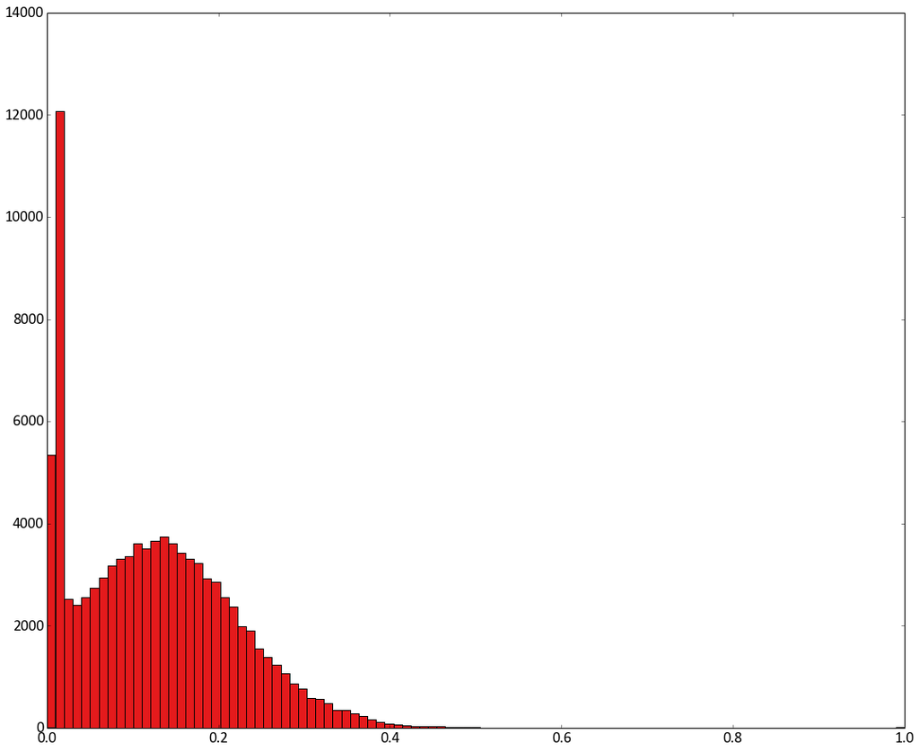

```python
bins = np.linspace(0., 1., num=100)
f, ax = plt.subplots(figsize=(18, 15))
ax.hist(cibr[~np.isnan(cibr)].flatten(), bins=bins)
```

```python
saveout = True
f, ax = plt.subplots(figsize=(15, 25))
output = ax.pcolor(np.flipud(cibr), cmap='hot', vmin=0, vmax=5)
ax.set_title("%s %s fire: CIBR" % (fireyear, firename.capitalize()))
ax.set_aspect('equal')
ax.set_axis_off()
position=f.add_axes([0.05, 0.2, 0.85, 0.025])
#position=f.add_axes([0.05, 0.01, 0.85, 0.025])
plt.colorbar(output, orientation='horizontal', cax=position, ticks=range(0, 75, 5))
plt.tight_layout()
if saveout:
    outfile = os.path.join(outdir, "cibr_%s_plot.png" % fireyear)
    plt.savefig(outfile,  bbox_inches='tight', dpi=150)
    plt.close()
```

```
WARNING:pygaarst.irutils:NaN generated while calculating normalized difference index: : Warning: invalid value encountered in less
```

## Fire detection with potassium emission feature: Kemiss

```python
kemiss = np.divide(hypsc.band42.radiance, hypsc.band43.radiance)
```

```
WARNING:pygaarst.irutils:NaN generated while calculating normalized difference index: : Warning: invalid value encountered in divide
```

## Calculate spectra

### Preparation

How long does it take to calculate 1 spectrum? This is mostly an I/O problem as the individual bands still reside in different data files.

```python
%%timeit
spec1 = hypsc.spectrum(i_fire[45], j_fire[45], bands='selected', bdsel=range(127, 224))
```

```
1 loops, best of 3: 1.13 s per loop
```

### Fire pixels (candidates)

Calculate default spectra for fire pixels. Default means only calibrated bands. How many did we get?

```python
with open(infn, "rU") as source:
    specs = pickle.load(source)
```

```python
loadfromfile = True
calculate = False
if loadfromfile:
    try:
        infn = os.path.join(outdir, "%s_firespecs.dat" % firename)
        with open(infn, "rU") as source:
            specs = pickle.load(source)
    except IOError:
        calculate = True
if (calculate or not loadfromfile):
    specs = [hypsc.spectrum(i, j) for i, j in zip(i_fire, j_fire)]
```

```python
print(len(specs), len(i_fire))
print(type(specs[0][0]), len(specs[0]))
print(type(specs), type(specs[0]))
```

[output not shown]

Alternative: save spectra to HDF5 file.

```python
outfn = os.path.join(outdir, "%s_firespecs_calib.hdf5" % firename)
rh.save_hypspec_to_hdf5(outfn, hypsc, specs, i_fire, j_fire)
```

```python
np.where(hypsc.band_is_calibrated)
```

```
(array([  7,   8,   9,  10,  11,  12,  13,  14,  15,  16,  17,  18,  19,
        20,  21,  22,  23,  24,  25,  26,  27,  28,  29,  30,  31,  32,
        33,  34,  35,  36,  37,  38,  39,  40,  41,  42,  43,  44,  45,
        46,  47,  48,  50,  52,  54,  56,  58,  60,  61,  62,  63,  64,
        65,  67,  69,  71,  73,  75,  77,  79,  81,  83,  85,  87,  89,
        91,  92,  93,  94,  95,  96,  97,  98,  99, 100, 101, 102, 103,
       104, 105, 106, 107, 108, 109, 110, 111, 112, 113, 114, 115, 116,
       117, 118, 119, 120, 121, 122, 123, 124, 125, 126, 127, 128, 129,
       130, 131, 132, 133, 134, 135, 136, 137, 138, 139, 140, 141, 142,
       143, 144, 145, 146, 147, 148, 149, 150, 151, 152, 153, 154, 155,
       156, 157, 158, 159, 160, 161, 162, 163, 164, 165, 166, 167, 168,
       169, 170, 171, 172, 173, 174, 175, 176, 177, 178, 179, 180, 181,
       182, 183, 184, 185, 186, 187, 188, 189, 190, 191, 192, 193, 194,
       195, 196, 197, 198, 199, 200, 201, 202, 203, 204, 205, 206, 207,
       208, 209, 210, 211, 212, 213, 214, 215, 216, 217, 218, 219, 220,
       221, 222, 223]),)
```

Pickle results.

```python
import pickle
out = os.path.join(outdir, "%s_firespecs.dat" % firename)
with open(out, "w") as sink:
    pickle.dump(specs, sink)
```

As it turns out, the high uncalibrated spectra don't contain any usable data at all. We'll neglect them from now on.

### Buffer pixels

Pull sample from buffer pixels (that is, not fire pixels, within buffer from fire pixels) if there is no saved data file. These represent "background" candidates.

```python
N=100
loadfromfile = True
if loadfromfile:
    fn = os.path.join(outdir, "%s_buffersample.txt" % firename)
    with open(fn, "rU") as source:
        for line in source:
            if line.startswith('#'):
                continue
            buffersample = json.loads(line)
else:
    i_buffer, j_buffer = np.where(firemask_ext == 0.5)
    buffersample = random.sample(zip(i_buffer, j_buffer), N)
print(buffersample)
```

```
[[226, 445], [130, 538], [377, 418], [281, 285], [330, 196], [135, 433], [40, 467], [319, 415], [368, 349], [597, 383], [156, 471], [243, 265], [321, 217], [316, 417], [303, 436], [329, 217], [499, 177], [120, 445], [516, 170], [182, 417], [376, 359], [47, 477], [597, 388], [302, 439], [277, 289], […
```

Save buffer sample to file.

```python
import json
out = os.path.join(outdir, "%s_buffersample.txt" % firename)
with open(out, "w") as sink:
    sink.write("#i and j coordinates for random sample from buffer pixels around fire candidate pixels, %s\n" % firename.capitalize())
    sink.write(json.dumps(buffersample))
```

Calculate spectra at buffer sample pixels.

```python
loadfromfile = False
calculate = False

if loadfromfile:
    try:
        infn = os.path.join(outdir, "%s_bufferspecs.dat" % firename)
        with open(infn, "rU") as source:
            specs_buffer = pickle.load(source)
    except IOError:
        calculate = True
if (calculate or not loadfromfile):
    specs_buffer = [hypsc.spectrum(i, j) for i, j in buffersample]
```

Alternatively, calculate spectra for ALL buffer pixels.

```python
i_buffer, j_buffer = np.where(firemask_ext == 0.5)
bufferall = zip(i_buffer, j_buffer)
print(len(bufferall))

loadfromfile = False
calculate = False

if loadfromfile:
    try:
        infn = os.path.join(outdir, "%s_bufferallspecs.dat" % firename)
        with open(infn, "rU") as source:
            specs_bufferall = pickle.load(source)
    except IOError:
        calculate = True
if (calculate or not loadfromfile):
    specs_bufferall = [hypsc.spectrum(i, j) for i, j in bufferall]
```

```
20109
```

```python
specs_bufferall[0]
```

[output not shown]

[output cut: 143 more lines]

[output not shown]

Pickle spectra.

```python
out = os.path.join(outdir, "%s_bufferspecs.dat" % firename)
with open(out, "w") as sink:
    pickle.dump(specs_buffer, sink)
```

[output not shown]

```python
out = os.path.join(outdir, "%s_bufferallspecs_calib.dat" % firename)
with open(out, "w") as sink:
    pickle.dump(bufferall, sink)
```

Save to HDF5 file.

```python
outfn = os.path.join(outdir, "%s_bufferallspecs_calib.hdf5" % firename)
rh.save_hypspec_to_hdf5(outfn, hypsc, specs_bufferall, i_buffer, j_buffer)
```

```python
i_buffersample = np.array([item[0] for item in buffersample])
j_buffersample = np.array([item[1] for item in buffersample])
outfn = os.path.join(outdir, "%s_buffersamplespecs_calib.hdf5" % firename)
specs_buffer_arr = np.array(specs_buffer)
rh.save_hypspec_to_hdf5(outfn, hypsc, specs_buffer_arr, i_buffersample, j_buffersample)
```

### Outside pixels

```python
N=100
loadfromfile = True
if loadfromfile:
    fn = os.path.join(outdir, "%s_outsidesample.txt" % firename)
    with open(fn, "rU") as source:
        for line in source:
            if line.startswith('#'):
                continue
            outsidesample = json.loads(line)
else:
    i_outside, j_outside = np.where(firemask_ext == 0)
    outsidesample = random.sample(zip(i_outside, j_outside), N)
print(outsidesample)
```

```
[[133, 113], [304, 305], [272, 260], [110, 314], [217, 313], [115, 167], [161, 317], [60, 271], [101, 294], [129, 301], [16, 274], [33, 252], [129, 96], [157, 321], [340, 261], [145, 344], [255, 267], [135, 339], [279, 207], [4, 42], [332, 291], [15, 184], [70, 49], [86, 16], [168, 326], [150, 22], …
```

```python
import json
out = os.path.join(outdir, "%s_outsidesample.txt" % firename)
with open(out, "w") as sink:
    sink.write("#i and j coordinates for random sample from pixels other than fire or buffer pixel, %s\n" % firename.capitalize())
    sink.write(json.dumps(outsidesample))
```

```python
loadfromfile = True

if loadfromfile:
    try:
        infn = os.path.join(outdir, "%s_outsidespecs.dat" % firename)
        with open(infn, "rU") as source:
            specs_outside = pickle.load(source)
    except IOError:
        calculate = True
if (calculate or not loadfromfile):
    specs_outside = [hypsc.spectrum(i, j) for i, j in outsidesample]
```

Pickle spectra.

```python
out = os.path.join(outdir, "%s_outsidespecs.dat" % firename)
with open(out, "w") as sink:
    pickle.dump(specs_outside, sink)
```

## Plot spectra

Fire candidate pixels first: loop through fire (candidate) pixel sectra, retrieve mod HDFI and CIBR, plot.

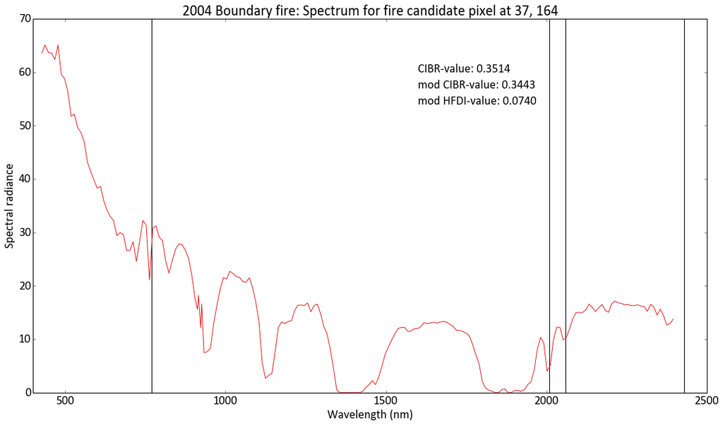

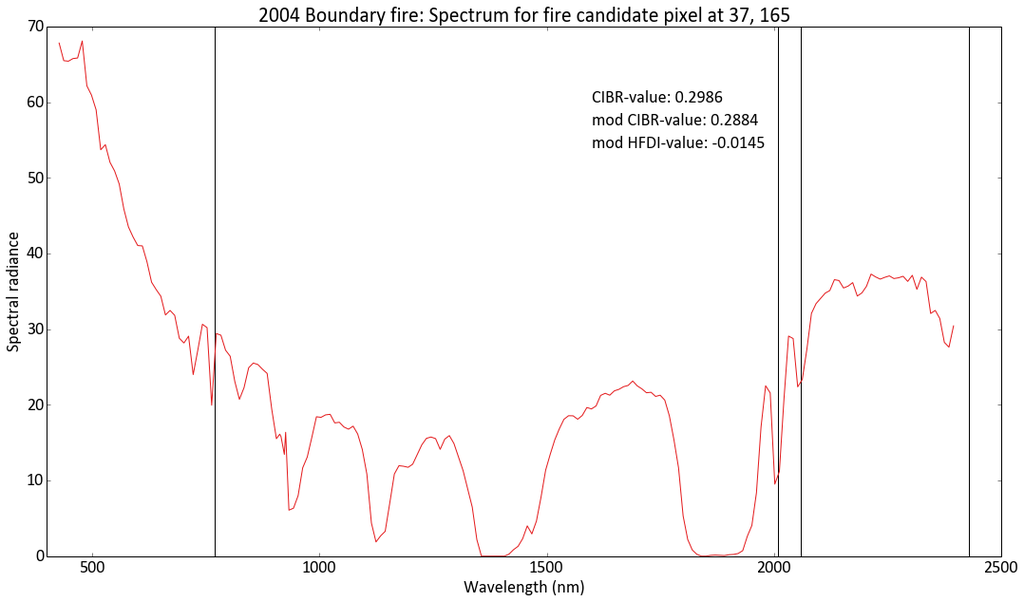

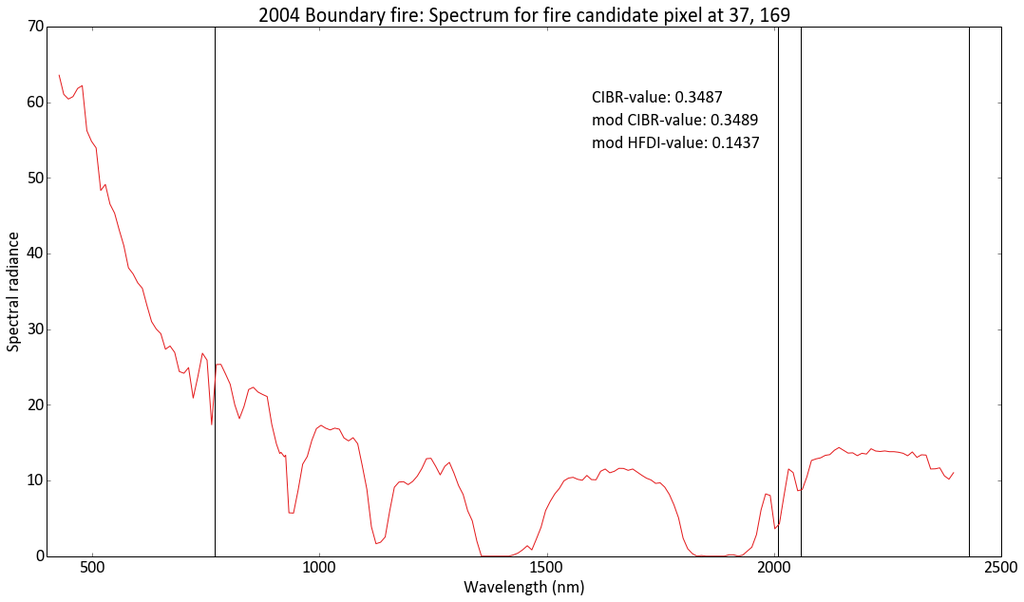

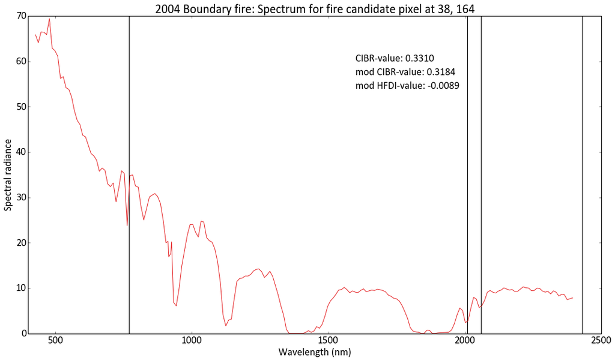

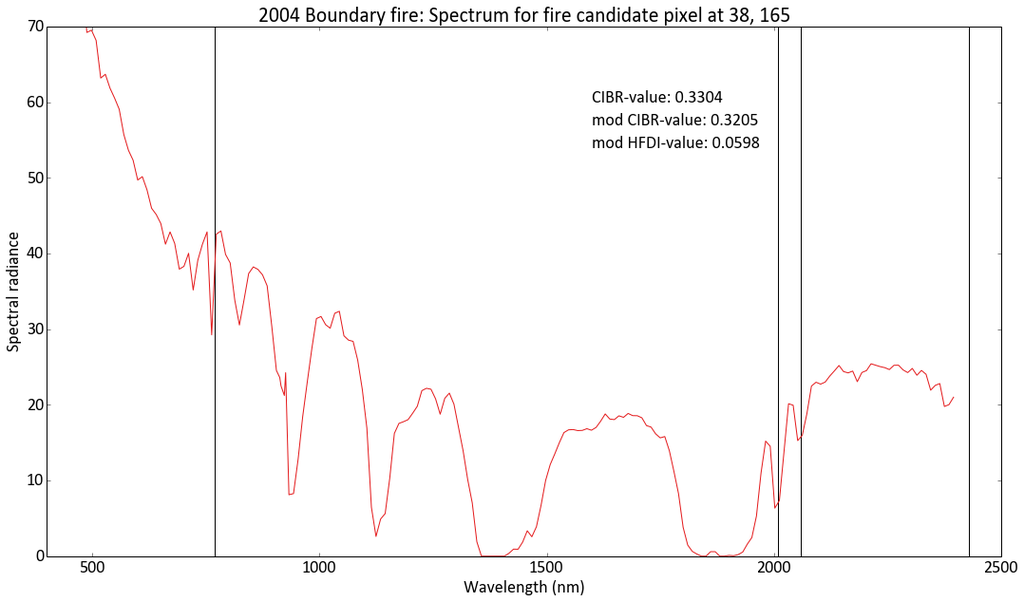

```python
saveout = False
for idx, spec in enumerate(specs[50:55]):
    f, ax = plt.subplots(1, 1, figsize=(18, 10))
    ax.set_xlabel("Wavelength (nm)")
    ax.set_ylabel("Spectral radiance")
    ax.set_xlim(400, 2500)
    ax.set_ylim(0, 70)
    ax.set_title("%s %s fire: Spectrum for fire candidate pixel at %s, %s" % (fireyear, firename.capitalize(), i_fire[idx], j_fire[idx]))
    ax.plot(hypsc.calibratedwavelength_nm, spec)
    #ax.plot(highwavelengths, specs_high[idx], linewidth=5)
    ax.vlines([770, 2010, 2060, 2430], [0, 0, 0, 0], [70, 70, 70, 70])
    #ax.text(1600, 60, "HFDI-value: %.4f" % hfdi[i_fire[idx], j_fire[idx]])
    ax.text(1600, 54, "mod HFDI-value: %.4f" % hfdi2[i_fire[idx], j_fire[idx]])
    ax.text(1600, 60, "CIBR-value: %.4f" % cibr[i_fire[idx], j_fire[idx]])
    ax.text(1600, 57, "mod CIBR-value: %.4f" % cibr2[i_fire[idx], j_fire[idx]])
    if saveout:
        outfile = os.path.join(outdir, "%s_spectrum_full_%s_%s.png" % (firename, i_fire[idx], j_fire[idx]))
        plt.savefig(outfile,  bbox_inches='tight', dpi=150)
        plt.close()
```

Plot spectra around the CO2 absorption feature to investigate it further.

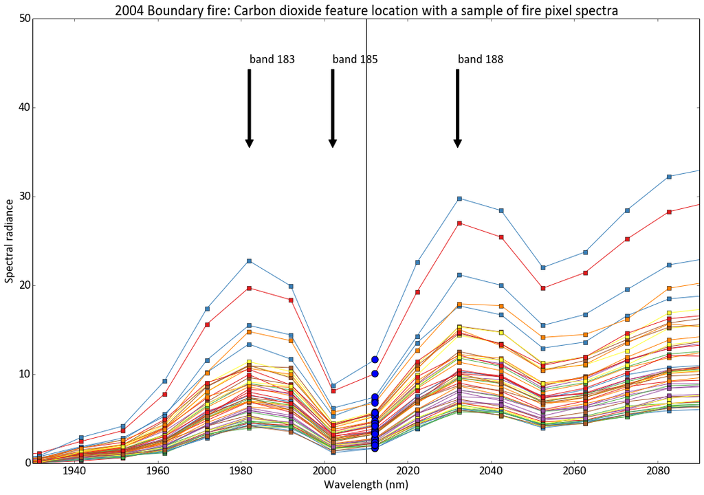

```python
idx_co2, bandname, hyp_co2 = hyp.find_nearest_hyp(2010)
idx_spec = np.where(hypsc.calibratedwavelength_nm == hyp_co2)[0]
saveout = False
f, ax = plt.subplots(1, 1, figsize=(18, 12))
ax.set_xlabel("Wavelength (nm)")
ax.set_ylabel("Spectral radiance")
ax.set_xlim(1930, 2090)
ax.set_ylim(0, 50)
ax.set_title("%s %s fire: Carbon dioxide feature location with a sample of fire pixel spectra" % (fireyear, firename.capitalize()))
ax.vlines(2010, 0, 70)
ax.annotate('band 185', xy=(2002, 35), xytext=(2002, 45),
        arrowprops=dict(facecolor='black', shrink=0.05),
        )
ax.annotate('band 188', xy=(2032, 35), xytext=(2032, 45),
        arrowprops=dict(facecolor='black', shrink=0.05),
        )
ax.annotate('band 183', xy=(1982, 35), xytext=(1982, 45),
        arrowprops=dict(facecolor='black', shrink=0.05),
        )
for idx, spec in enumerate(specs[100:150]):
    ax.plot(hypsc.calibratedwavelength_nm, spec, 's-')
    ax.scatter(hyp_co2, spec[idx_spec], zorder=5, marker='o', s=100)
#    ax.plot(highwavelengths, specs_high[idx], linewidth=5)
    if saveout:
        outfile = os.path.join(outdir, "%s_co2_fire_sample.png" % firename)
        plt.savefig(outfile,  dpi=150)
        plt.close()
```

Plot spectra around the potassium emission feature around 770 nm.

[output not shown]

[figure not shown]

```python
idx_k, bandname_k, hyp_k = hyp.find_nearest_hyp(770)
idx_spec = np.where(hypsc.calibratedwavelength_nm == hyp_k)[0]
saveout = True
f, ax = plt.subplots(1, 1, figsize=(18, 12))
ax.set_xlabel("Wavelength (nm)")
ax.set_ylabel("Spectral radiance")
ax.set_xlim(720, 820)
ax.set_ylim(0, 70)
ax.set_title("%s %s fire: Potassium feature location with a sample of fire pixel spectra" % (fireyear, firename.capitalize()))
ax.vlines(770, 0, 70)
#ax.annotate('band 185', xy=(2002, 35), xytext=(2002, 45),
#        arrowprops=dict(facecolor='black', shrink=0.05),
#        )
#ax.annotate('band 188', xy=(2032, 35), xytext=(2032, 45),
#        arrowprops=dict(facecolor='black', shrink=0.05),
#        )
#ax.annotate('band 183', xy=(1982, 35), xytext=(1982, 45),
#        arrowprops=dict(facecolor='black', shrink=0.05),
#        )
for idx, spec in enumerate(specs[100:150]):
    ax.plot(hypsc.calibratedwavelength_nm, spec, 's-')
    ax.scatter(hyp_co2, spec[idx_spec], zorder=5, marker='o', s=100)
#    ax.plot(highwavelengths, specs_high[idx], linewidth=5)
    if saveout:
        outfile = os.path.join(outdir, "%s_K_fire_sample.png" % firename)
        plt.savefig(outfile,  dpi=150)
        plt.close()
```

Plot spectra for buffer pixels.

```python
saveout = True
for idx, spec in enumerate(specs_buffer):
    f, ax = plt.subplots(1, 1, figsize=(18, 10))
    ax.set_xlabel("Wavelength (nm)")
    ax.set_ylabel("Spectral radiance")
    ax.set_xlim(400, 2500)
    ax.set_ylim(0, 70)
    ax.set_title("%s %s fire: Spectrum for background candidate pixel at %s, %s" % (fireyear, firename.capitalize(), buffersample[idx][0], buffersample[idx][1]))
    ax.plot(hypsc.calibratedwavelength_nm, spec)
    ax.vlines([770, 2010, 2060, 2430], [0, 0, 0, 0], [70, 70, 70, 70])
    ax.text(1600, 54, "mod HFDI-value: %.4f" % hfdi2[i_fire[idx], j_fire[idx]])
    ax.text(1600, 60, "CIBR-value: %.4f" % cibr[i_fire[idx], j_fire[idx]])
    ax.text(1600, 57, "mod CIBR-value: %.4f" % cibr2[i_fire[idx], j_fire[idx]])
    if saveout:
        outfile = os.path.join(outdir, "%s_spectrum_full_buffer_%s_%s.png" % (firename, i_fire[idx], j_fire[idx]))
        plt.savefig(outfile,  bbox_inches='tight', dpi=150)
        plt.close()
```

[figure not shown]

```python
idx_co2, bandname, hyp_co2 = hyp.find_nearest_hyp(2010)
idx_spec = np.where(hypsc.calibratedwavelength_nm == hyp_co2)[0]
saveout = False
f, ax = plt.subplots(1, 1, figsize=(18, 12))
ax.set_xlabel("Wavelength (nm)")
ax.set_ylabel("Spectral radiance")
ax.set_xlim(1930, 2090)
ax.set_ylim(0, 10)
ax.set_title("%s %s fire: Carbon dioxide feature location with a sample of background spectra" % (fireyear, firename.capitalize()))
ax.vlines(2010, 0, 10)
ax.annotate('band 185', xy=(2002, 5), xytext=(2002, 7),
        arrowprops=dict(facecolor='black', shrink=0.05),
        )
ax.annotate('band 188', xy=(2032, 5), xytext=(2032, 7),
        arrowprops=dict(facecolor='black', shrink=0.05),
        )
ax.annotate('band 183', xy=(1982, 5), xytext=(1982, 7),
        arrowprops=dict(facecolor='black', shrink=0.05),
        )
for idx, spec in enumerate(specs_buffer[:10]):
    ax.plot(hypsc.calibratedwavelength_nm, spec, 's-')
    ax.scatter(hyp_co2, spec[idx_spec], zorder=5, marker='o', s=100)
    if saveout:
        outfile = os.path.join(outdir, "%s_spectrum_full_%s_%s.png" % (firename, i_fire[idx], j_fire[idx]))
        plt.savefig(outfile,  bbox_inches='tight', dpi=150)
        plt.close()
```

Now for outside pixels.

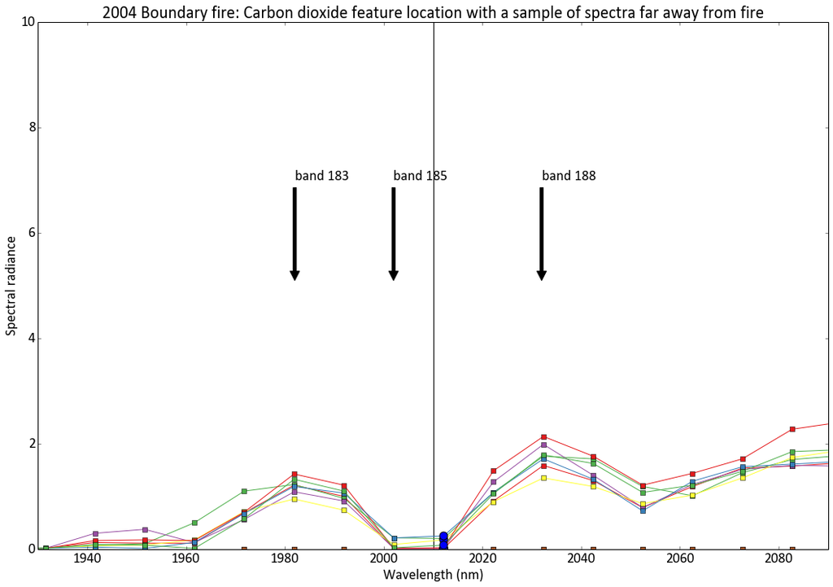

```python
idx_co2, bandname, hyp_co2 = hyp.find_nearest_hyp(2010)
idx_spec = np.where(hypsc.calibratedwavelength_nm == hyp_co2)[0]
saveout = False
f, ax = plt.subplots(1, 1, figsize=(18, 12))
ax.set_xlabel("Wavelength (nm)")
ax.set_ylabel("Spectral radiance")
ax.set_xlim(1930, 2090)
ax.set_ylim(0, 10)
ax.set_title("%s %s fire: Carbon dioxide feature location with a sample of spectra far away from fire" % (fireyear, firename.capitalize()))
ax.vlines(2010, 0, 10)
ax.annotate('band 185', xy=(2002, 5), xytext=(2002, 7),
        arrowprops=dict(facecolor='black', shrink=0.05),
        )
ax.annotate('band 188', xy=(2032, 5), xytext=(2032, 7),
        arrowprops=dict(facecolor='black', shrink=0.05),
        )
ax.annotate('band 183', xy=(1982, 5), xytext=(1982, 7),
        arrowprops=dict(facecolor='black', shrink=0.05),
        )
for idx, spec in enumerate(specs_outside[:10]):
    ax.plot(hypsc.calibratedwavelength_nm, spec, 's-')
    ax.scatter(hyp_co2, spec[idx_spec], zorder=5, marker='o', s=100)
    if saveout:
        outfile = os.path.join(outdir, "%s_spectrum_outside_full_%s_%s.png" % (firename, i_fire[idx], j_fire[idx]))
        plt.savefig(outfile,  bbox_inches='tight', dpi=150)
        plt.close()
```

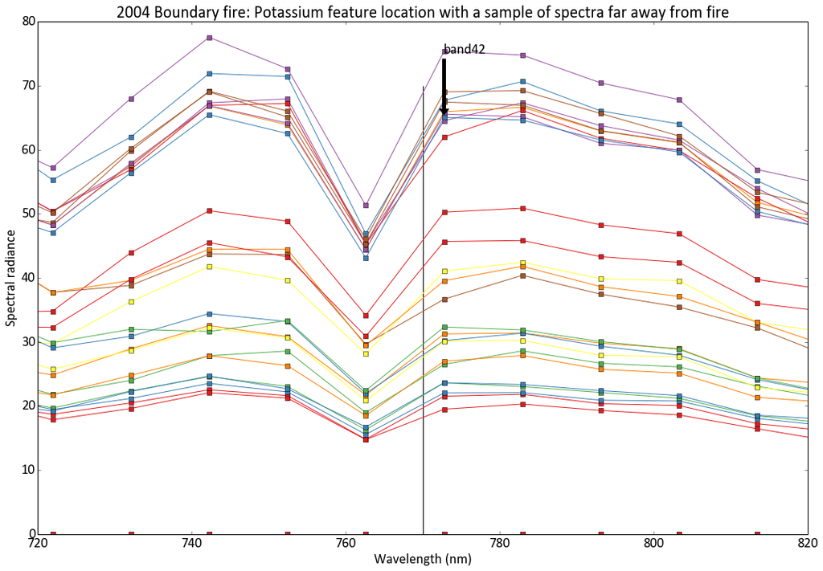

```python
idx_k, bandname_k, hyp_k = hyp.find_nearest_hyp(770)
idx_spec = np.where(hypsc.calibratedwavelength_nm == hyp_k)[0]
saveout = False
f, ax = plt.subplots(1, 1, figsize=(18, 12))
ax.set_xlabel("Wavelength (nm)")
ax.set_ylabel("Spectral radiance")
ax.set_xlim(720, 820)
ax.set_ylim(0, 80)
ax.set_title("%s %s fire: Potassium feature location with a sample of spectra far away from fire" % (fireyear, firename.capitalize()))
ax.vlines(770, 0, 70)
ax.annotate(bandname_k, xy=(hyp_k, 65), xytext=(hyp_k, 75),
        arrowprops=dict(facecolor='black', shrink=0.05),
        )
#ax.annotate('band 188', xy=(2032, 35), xytext=(2032, 45),
#        arrowprops=dict(facecolor='black', shrink=0.05),
#        )
#ax.annotate('band 183', xy=(1982, 35), xytext=(1982, 45),
#        arrowprops=dict(facecolor='black', shrink=0.05),
#        )
for idx, spec in enumerate(specs_outside[10:60]):
    ax.plot(hypsc.calibratedwavelength_nm, spec, 's-')
    ax.scatter(hyp_co2, spec[idx_spec], zorder=5, marker='o', s=100)
#    ax.plot(highwavelengths, specs_high[idx], linewidth=5)
    if saveout:
        outfile = os.path.join(outdir, "%s_K_outside_sample.png" % firename)
        plt.savefig(outfile,  dpi=150)
        plt.close()
```

## Quality of fire indices

Average CIBR for fire and buffer pixels.

```python
cibrs_outside = np.array([cibr2[i, j] for i, j in outsidesample])
cibrs_buff = np.array([cibr2[i, j] for i, j in buffersample])
cibrs_fire = np.array([cibr2[i, j] for i, j in zip(i_fire, j_fire)])
mean_outside, std_outside = np.mean(cibrs_outside[~np.isnan(cibrs_outside)]), np.std(cibrs_outside[~np.isnan(cibrs_outside)])
mean_buff, std_buff = np.mean(cibrs_buff[~np.isnan(cibrs_buff)]), np.std(cibrs_buff[~np.isnan(cibrs_buff)])
mean_fire, std_fire = np.mean(cibrs_fire), np.std(cibrs_fire)
print(mean_outside, std_outside)
print(mean_buff, std_buff)
print(mean_fire, std_fire)
```

```
(0.11061936, 0.082325585)
(0.12504987, 0.083247416)
(0.33778536, 0.079915613)
```

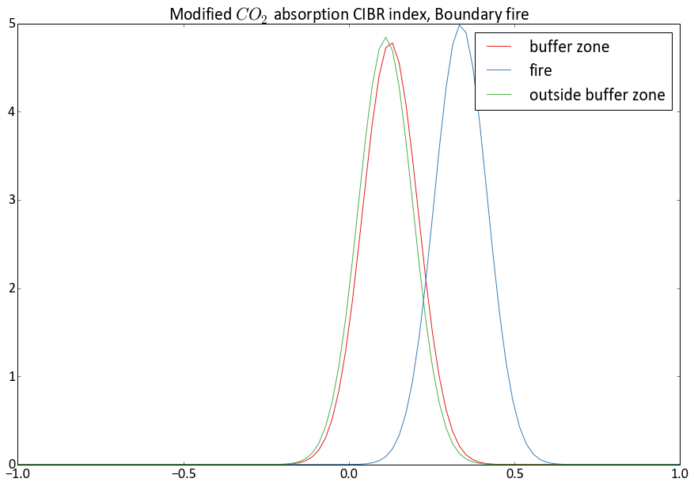

```python
f, ax = plt.subplots(1, 1, figsize=(15, 10))
ax.plot(np.linspace(-1, 1, 100), stats.norm.pdf(np.linspace(-1, 1, 100), mean_buff, std_buff), label='buffer zone')
ax.plot(np.linspace(-1, 1, 100), stats.norm.pdf(np.linspace(-1, 1, 100), mean_fire, std_fire), label='fire')
ax.plot(np.linspace(-1, 1, 100), stats.norm.pdf(np.linspace(-1, 1, 100), mean_outside, std_outside), label='outside buffer zone')
ax.legend()
ax.set_title("Modified $CO_2$ absorption CIBR index, %s fire" % firename.capitalize())
```

Same for mod HDMI

```python
hfdi2s_outside = np.array([hfdi2[i, j] for i, j in outsidesample])
hfdi2s_buff = np.array([hfdi2[i, j] for i, j in buffersample])
hfdi2s_fire = np.array([hfdi2[i, j] for i, j in zip(i_fire, j_fire)])
mean_outside, std_outside = np.mean(hfdi2s_outside[~np.isnan(hfdi2s_outside)]), np.std(hfdi2s_outside[~np.isnan(hfdi2s_outside)])
mean_buff, std_buff = np.mean(hfdi2s_buff[~np.isnan(hfdi2s_buff)]), np.std(hfdi2s_buff[~np.isnan(hfdi2s_buff)])
mean_fire, std_fire = np.mean(hfdi2s_fire), np.std(hfdi2s_fire)
print(mean_outside, std_outside)
print(mean_buff, std_buff)
print(mean_fire, std_fire)
```

```
(-0.31852448, 0.36618954)
(-0.28128362, 0.32938206)
(0.053092424, 0.1392234)
```

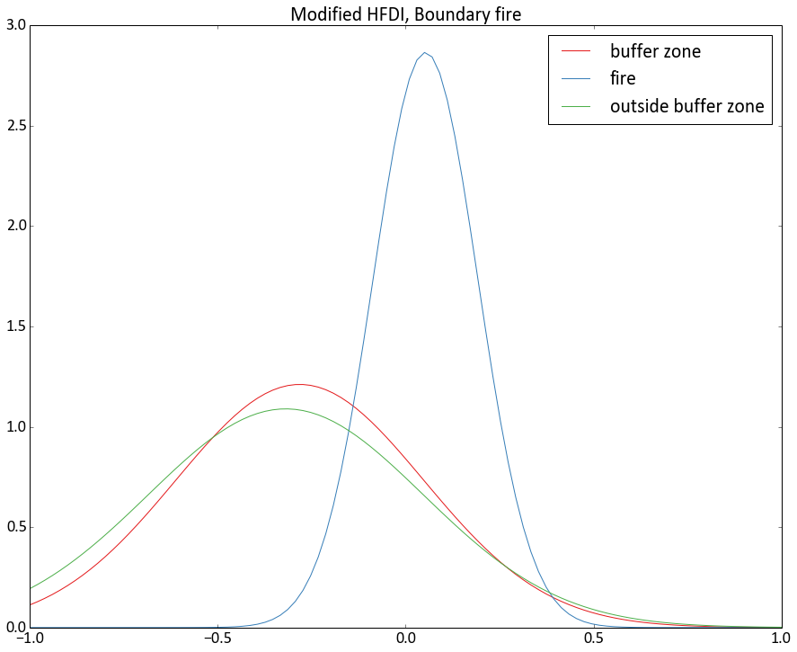

```python
f, ax = plt.subplots(1, 1, figsize=(15, 12))
ax.plot(np.linspace(-1, 1, 100), stats.norm.pdf(np.linspace(-1, 1, 100), mean_buff, std_buff), label='buffer zone')
ax.plot(np.linspace(-1, 1, 100), stats.norm.pdf(np.linspace(-1, 1, 100), mean_fire, std_fire), label='fire')
ax.plot(np.linspace(-1, 1, 100), stats.norm.pdf(np.linspace(-1, 1, 100), mean_outside, std_outside), label='outside buffer zone')
ax.legend()
ax.set_title("Modified HFDI, %s fire" % firename.capitalize())
```

Same for kemiss

```python
kemiss_outside = np.array([kemiss[i, j] for i, j in outsidesample])
kemiss_buff = np.array([kemiss[i, j] for i, j in buffersample])
kemiss_fire = np.array([kemiss[i, j] for i, j in zip(i_fire, j_fire)])
mean_outside, std_outside = np.mean(kemiss_outside[~np.isnan(kemiss_outside)]), np.std(kemiss_outside[~np.isnan(kemiss_outside)])
mean_buff, std_buff = np.mean(kemiss_buff[~np.isnan(kemiss_buff)]), np.std(kemiss_buff[~np.isnan(kemiss_buff)])
mean_fire, std_fire = np.mean(kemiss_fire), np.std(kemiss_fire)
print(mean_outside, std_outside)
print(mean_buff, std_buff)
print(mean_fire, std_fire)
```

```
(0.97515625, 0.029731005)
(0.9930675, 0.020570677)
(0.99585849, 0.016047871)
```

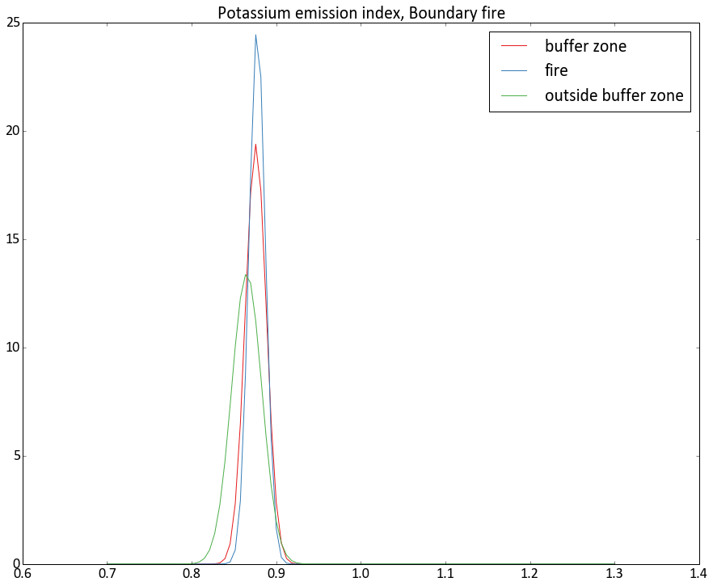

```python
f, ax = plt.subplots(1, 1, figsize=(15, 12))
ax.plot(np.linspace(0.7, 1.3, 100), stats.norm.pdf(np.linspace(0.7, 1.7, 100), mean_buff, std_buff), label='buffer zone')
ax.plot(np.linspace(0.7, 1.3, 100), stats.norm.pdf(np.linspace(0.7, 1.7, 100), mean_fire, std_fire), label='fire')
ax.plot(np.linspace(0.7, 1.3, 100), stats.norm.pdf(np.linspace(0.7, 1.7, 100), mean_outside, std_outside), label='outside buffer zone')
ax.legend()
ax.set_title("Potassium emission index, %s fire" % firename.capitalize())
```

## Classify spectra

Load buffer pixel, and fire pixel. Then merge. Filter out rows of all zero (these are from the no-data areas).

```python
infn = os.path.join(outdir, "%s_bufferallspecs_calib.hdf5" % firename)
with h5py.File(infn, "r") as infh:
    spectest = infh['spectrum'][:, 98:]
    i_buff = infh['i_row_idx'][...]
    j_buff = infh['j_col_idx'][...]
    wav = infh['bandwavelenght_nm'][98:]
    bandnames = infh['bandname'][98:]
minspec = np.min(spectest, axis=0)
spectest = spectest[np.any(spectest > 0, axis=1)]
```

```python
print(bandnames[0])
```

```
band125
```

```python
infn = os.path.join(outdir, "%s_firespecs_calib.hdf5" % firename)
with h5py.File(infn, "r") as infh:
    specfire = infh['spectrum'][:, 98:]
    i_fire = infh['i_row_idx'][...]
    j_fire = infh['j_col_idx'][...]
```

```python
specs = np.concatenate((spectest, specfire))
i = np.concatenate((i_buff, i_fire))
j = np.concatenate((j_buff, j_fire))
coords = np.array(zip(i, j))
```

```python
print(specs.shape, coords.size, coords.shape)
```

```
((12219, 100), 24520, (12260, 2))
```

Plot a sample of all spectra.

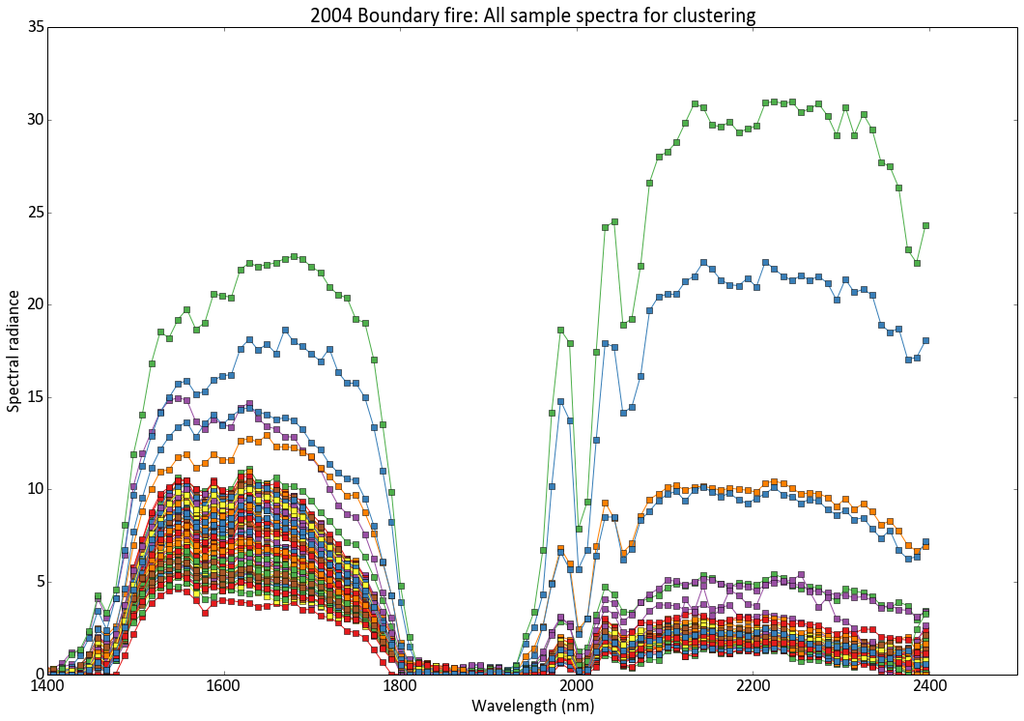

```python
saveout = False
plotsample = random.sample(specs, 100)

f, ax = plt.subplots(1, 1, figsize=(18, 12))
ax.set_xlabel("Wavelength (nm)")
ax.set_ylabel("Spectral radiance")
ax.set_xlim(1400, 2500)
#ax.set_ylim(0, 10)
ax.set_title("%s %s fire: All sample spectra for clustering" % (fireyear, firename.capitalize()))
for spec in plotsample:
    ax.plot(wav, spec, 's-')
if saveout:
    outfile = os.path.join(outdir, "%s_spectrum_mbk_data02.npz" % firename)
    if os.path.exists(outfile):
        raise Exception("Won't overwrite %s." % outfile)
    np.savez(outfile, mbk_means_labels=mbk_means_labels, mbk_means_cluster_centers=mbk_means_cluster_centers, coords=coords)
    outfile = os.path.join(outdir, "%s_spectrum_mbk_clustercenters02.png" % firename)
    plt.savefig(outfile,  bbox_inches='tight', dpi=150)
    plt.close()
```

```python
from sklearn.cluster import DBSCAN
from sklearn import metrics

db = DBSCAN(min_samples=2).fit(specs)
core_samples = db.core_sample_indices_
labels = db.labels_

# Number of clusters in labels, ignoring noise if present.
n_clusters_ = len(set(labels)) - (1 if -1 in labels else 0)

print('Estimated number of clusters: %d' % n_clusters_)
```

```
Estimated number of clusters: 0
```

```python
with np.load(os.path.join(outdir, "%s_spectrum_mbk_data01.npz" % firename)) as npzfile:
    for fl in npzfile.files:
        print(fl)
    mbk_means_cluster_centers = npzfile['mbk_means_cluster_centers']
    mbk_means_labels = npzfile['mbk_means_labels']
    coords = npzfile['coords']


batch_size = 20
mbk = MiniBatchKMeans(init='k-means++', n_clusters=6, batch_size=batch_size,
                      n_init=1000, max_no_improvement=1000, verbose=False)
t0 = time.time()
mbk.fit(specs)
t_mini_batch = time.time() - t0
mbk_means_labels = mbk.labels_
mbk_means_cluster_centers = mbk.cluster_centers_
mbk_means_labels_unique = np.unique(mbk_means_labels)
```

```
mbk_means_cluster_centers
mbk_means_labels
coords
```

Fit from scratch

```python
from sklearn.cluster import MiniBatchKMeans
import time

batch_size = 20
mbk = MiniBatchKMeans(init='k-means++', n_clusters=6, batch_size=batch_size,
                      n_init=1000, max_no_improvement=1000, verbose=False)
t0 = time.time()
mbk.fit(specs)
t_mini_batch = time.time() - t0
mbk_means_labels = mbk.labels_
mbk_means_cluster_centers = mbk.cluster_centers_
mbk_means_labels_unique = np.unique(mbk_means_labels)
```